# Ecuador varcode paper: bayesian PTS

Shazia Ruybal-Pesantez

## Background

The purpose of this analysis was to calculate pairwise bayesian pairwise type sharing ($BP_{TS}$, Johnson et al *in prep* and inspired by BRO from [Larremore 2019](https://doi.org/10.1371/journal.pcbi.1006898)), to account for uncertainty in pairwise comparisons when calculating $P_{TS}$ as per [Barry et al 2007](https://doi.org/10.1371/journal.ppat.0030034) and [He et al 2018](https://doi.org/10.1038/s41467-018-04219-3). In our analysis, we calculate PTS “directionally” to account for variability in sampling across isolates, such that $n_{a}$/$n_{a}$ (comparing a to b) can differ from $n_{a}$/$n_{b}$ (comparing b to a) - as a simple example: if $n_{a}$=30, $n_{b}$=40, $n_{a}$=10, $P_{TS}$ would be 0.33 and 0.25 depending on the comparison.

$BP_{TS}$ provides an unbiased estimate of repertoire overlap (i.e. the number of *var* types shared by a given pair of isolates) by accounting for the uncertainty of those estimates due to sample size (i.e. repertoire size).

### Import bayesian results

These results have been provided by Erik Johnson and Dan Larremore, collaborators at University of Colorado.

For each (na,nb,nab) triplet, the posterior samples are triplets (s, Ra, Rb) where s is the number of shared genes (i.e., repertoire overlap), and Ra and Rb are the total repertoire sizes for parasite a and b. The results file contains the following variables:

- `s_mean`: the mean of the s values
- `s_lower_95hpdi`: the lower cutoff value for the 95% highest posterior density region for s (which is a version of the posterior credible interval that is centered on the highest density part of the posterior, which is different from the “equal tail” intervals that we provided before)
- `s_upper_95hpdi`: the upper cutoff value for the 95% highest posterior density region for s
- `xb_mean`: the mean of the xb=s/Rb values
- `xb_lower_95hpdi`: the lower cutoff value for the 95% highest posterior density interval for xb=s/Rb
- `xb_upper_95hpdi`: the upper cutoff value for the 95% highest posterior density interval for xb=s/Rb
- `xa_mean`: the mean of the xa=s/Ra values
- `xa_lower_95hpdi`: the lower cutoff value for the 95% highest posterior density interval for xa=s/Ra
- `xa_upper_95hpdi`: the upper cutoff value for the 95% highest posterior density interval for xa=s/Ra
- `x_mean`: the mean of the x=2s/(Ra+Rb) values
- `x_lower_95hpdi`: the lower cutoff value for the 95% highest posterior density interval for x=2s/(Ra+Rb)
- `x_upper_95hpdi`: the upper cutoff value for the 95% highest posterior density interval for x=2s/(Ra+Rb)

## Analysis

For the Ecuador *var*code paper, we only considered one “direction” of the pairwise comparisons (i.e., “retrospective” comparisons, since we corrected for time order as a conservative approach to look at repertoire overlap/genetic relatedness). By focusing on “retrospective” $P_{TS}$ estimates we essentially compare each isolate to everything that was identified before it. For comparative analyses with the bayesian PTS, we will only focus on the `xa` results, which correspond to `s`/`Ra`, where `s` equals the mean of the `s` values, and `Ra` equals the repertoire size of the parasite identified later in time for a given pairwise comparison.

#### Differences between observed and estimated `s_mean` (i.e mean of the number of shared types)

```r
bayesian_orig %>%
  mutate(diff = n_shared_ab - s_mean) %>% summarise(min = min(diff),
                                                  med = median(diff),
                                                  mean = mean(diff),
                                                  max = max(diff))
```

| min | med | mean | max |
| --- | --- | --- | --- |
| -31.074 | -7.082667 | -8.237966 | -0.798 |

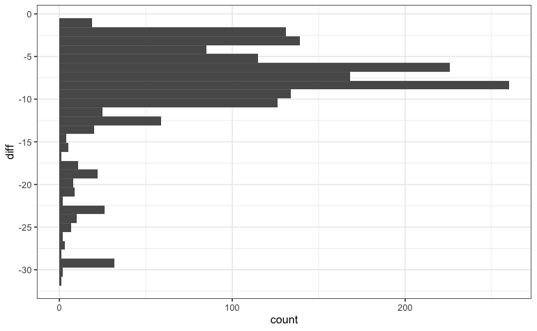

```r
bayesian_orig %>%
  mutate(diff = n_shared_ab - s_mean) %>%
  ggplot(aes(y = diff)) +
    geom_histogram() +
    scale_y_continuous(breaks = scales::pretty_breaks(n = 10)) +
    theme_bw()
```

#### Merge with epi data

```r
epi_mod1 <- ecu_epi %>% rename_at(names(.), function(x) paste0(x, "1"))
epi_mod2 <- ecu_epi %>% rename_at(names(.), function(x) paste0(x, "2"))
epi_formerge <- bind_cols(epi_mod1, epi_mod2)

bayesian_data <- bayesian_orig %>% inner_join(select(epi_formerge, ends_with("1")), by = c("case_a" = "Case1"))
bayesian_data <- bayesian_data %>% inner_join(select(epi_formerge, ends_with("2")), by = c("case_b" = "Case2"))
```

#### Create *var*code comparison variable

```r
bayesian_data <- bayesian_data %>%
  mutate(comparison =
           case_when(
             varcode1 == "varcode1" & varcode2 == "varcode1" ~ "varcode1 vs varcode1", #vc1
             varcode1 == "varcode2" & varcode2 == "varcode2" ~ "varcode2 vs varcode2", #vc2
             varcode1 == "varcode3" & varcode2 == "varcode3" ~ "varcode3 vs varcode3", #vc3
             varcode1 == "varcode4" & varcode2 == "varcode4" ~ "varcode4 vs varcode4", #vc4
             varcode1 == "varcode5" & varcode2 == "varcode5" ~ "varcode5 vs varcode5", #vc5
             varcode1 == "varcode6" & varcode2 == "varcode6" ~ "varcode6 vs varcode6", #vc6
             varcode1 == "varcode7" & varcode2 == "varcode7" ~ "varcode7 vs varcode7", #vc7
             varcode1 == "varcode8" & varcode2 == "varcode8" ~ "varcode8 vs varcode8", #vc8
             varcode1 == "varcode9" & varcode2 == "varcode9" ~ "varcode9 vs varcode9", #vc9
             varcode1 == "varcode1" & varcode2 == "varcode2" | varcode1 == "varcode2" & varcode2 == "varcode1" ~ "varcode1 vs varcode2", #1v2
             varcode1 == "varcode1" & varcode2 == "varcode3" | varcode1 == "varcode3" & varcode2 == "varcode1" ~ "varcode1 vs varcode3", #1v3
             varcode1 == "varcode1" & varcode2 == "varcode4" | varcode1 == "varcode4" & varcode2 == "varcode1" ~ "varcode1 vs varcode4", #1v4
             varcode1 == "varcode1" & varcode2 == "varcode5" | varcode1 == "varcode5" & varcode2 == "varcode1" ~ "varcode1 vs varcode5", #1v5
             varcode1 == "varcode1" & varcode2 == "varcode6" | varcode1 == "varcode6" & varcode2 == "varcode1" ~ "varcode1 vs varcode6", #1v6
             varcode1 == "varcode1" & varcode2 == "varcode7" | varcode1 == "varcode7" & varcode2 == "varcode1" ~ "varcode1 vs varcode7", #1v7
             varcode1 == "varcode1" & varcode2 == "varcode8" | varcode1 == "varcode8" & varcode2 == "varcode1" ~ "varcode1 vs varcode8", #1v8
             varcode1 == "varcode1" & varcode2 == "varcode9" | varcode1 == "varcode9" & varcode2 == "varcode1" ~ "varcode1 vs varcode9", #1v9
             varcode1 == "varcode2" & varcode2 == "varcode3" | varcode1 == "varcode3" & varcode2 == "varcode2" ~ "varcode2 vs varcode3", #2v3
             varcode1 == "varcode2" & varcode2 == "varcode4" | varcode1 == "varcode4" & varcode2 == "varcode2" ~ "varcode2 vs varcode4", #2v4
             varcode1 == "varcode2" & varcode2 == "varcode5" | varcode1 == "varcode5" & varcode2 == "varcode2" ~ "varcode2 vs varcode5", #2v5
             varcode1 == "varcode2" & varcode2 == "varcode6" | varcode1 == "varcode6" & varcode2 == "varcode2" ~ "varcode2 vs varcode6", #2v6
             varcode1 == "varcode2" & varcode2 == "varcode7" | varcode1 == "varcode7" & varcode2 == "varcode2" ~ "varcode2 vs varcode7", #2v7
             varcode1 == "varcode2" & varcode2 == "varcode8" | varcode1 == "varcode8" & varcode2 == "varcode2" ~ "varcode2 vs varcode8", #2v8
             varcode1 == "varcode2" & varcode2 == "varcode9" | varcode1 == "varcode9" & varcode2 == "varcode2" ~ "varcode2 vs varcode9", #2v9
             varcode1 == "varcode3" & varcode2 == "varcode4" | varcode1 == "varcode4" & varcode2 == "varcode3" ~ "varcode3 vs varcode4", #3v4
             varcode1 == "varcode3" & varcode2 == "varcode5" | varcode1 == "varcode5" & varcode2 == "varcode3" ~ "varcode3 vs varcode5", #3v5
             varcode1 == "varcode3" & varcode2 == "varcode6" | varcode1 == "varcode6" & varcode2 == "varcode3" ~ "varcode3 vs varcode6", #3v6
             varcode1 == "varcode3" & varcode2 == "varcode7" | varcode1 == "varcode7" & varcode2 == "varcode3" ~ "varcode3 vs varcode7", #3v7
             varcode1 == "varcode3" & varcode2 == "varcode8" | varcode1 == "varcode8" & varcode2 == "varcode3" ~ "varcode3 vs varcode8", #3v8
             varcode1 == "varcode3" & varcode2 == "varcode9" | varcode1 == "varcode9" & varcode2 == "varcode3" ~ "varcode3 vs varcode9", #3v9
             varcode1 == "varcode4" & varcode2 == "varcode5" | varcode1 == "varcode5" & varcode2 == "varcode4" ~ "varcode4 vs varcode5", #4v5
             varcode1 == "varcode4" & varcode2 == "varcode6" | varcode1 == "varcode6" & varcode2 == "varcode4" ~ "varcode4 vs varcode6", #4v6
             varcode1 == "varcode4" & varcode2 == "varcode7" | varcode1 == "varcode7" & varcode2 == "varcode4" ~ "varcode4 vs varcode7", #4v7
             varcode1 == "varcode4" & varcode2 == "varcode8" | varcode1 == "varcode8" & varcode2 == "varcode4" ~ "varcode4 vs varcode8", #4v8
             varcode1 == "varcode4" & varcode2 == "varcode9" | varcode1 == "varcode9" & varcode2 == "varcode4" ~ "varcode4 vs varcode9", #4v9
             varcode1 == "varcode5" & varcode2 == "varcode6" | varcode1 == "varcode6" & varcode2 == "varcode5" ~ "varcode5 vs varcode6", #5v6
             varcode1 == "varcode5" & varcode2 == "varcode7" | varcode1 == "varcode7" & varcode2 == "varcode5" ~ "varcode5 vs varcode7", #5v7
             varcode1 == "varcode5" & varcode2 == "varcode8" | varcode1 == "varcode8" & varcode2 == "varcode5" ~ "varcode5 vs varcode8", #5v8
             varcode1 == "varcode5" & varcode2 == "varcode9" | varcode1 == "varcode9" & varcode2 == "varcode5" ~ "varcode5 vs varcode9", #5v9
             varcode1 == "varcode6" & varcode2 == "varcode7" | varcode1 == "varcode7" & varcode2 == "varcode6" ~ "varcode6 vs varcode7", #6v7
             varcode1 == "varcode6" & varcode2 == "varcode8" | varcode1 == "varcode8" & varcode2 == "varcode6" ~ "varcode6 vs varcode8", #6v8
             varcode1 == "varcode6" & varcode2 == "varcode9" | varcode1 == "varcode9" & varcode2 == "varcode6" ~ "varcode6 vs varcode9", #6v9
             varcode1 == "varcode7" & varcode2 == "varcode8" | varcode1 == "varcode8" & varcode2 == "varcode7" ~ "varcode7 vs varcode8", #7v8
             varcode1 == "varcode7" & varcode2 == "varcode9" | varcode1 == "varcode9" & varcode2 == "varcode7" ~ "varcode7 vs varcode9", #7v9
             varcode1 == "varcode8" & varcode2 == "varcode9" | varcode1 == "varcode9" & varcode2 == "varcode8" ~ "varcode8 vs varcode9")) #8v9


within_comp <- list("varcode1 vs varcode1",
                    "varcode2 vs varcode2",
                    "varcode3 vs varcode3",
                    "varcode4 vs varcode4",
                    "varcode5 vs varcode5",
                    "varcode6 vs varcode6",
                    "varcode7 vs varcode7",
                    "varcode8 vs varcode8",
                    "varcode9 vs varcode9")

between_comp <- list("varcode1 vs varcode2",
                     "varcode1 vs varcode3",
                     "varcode1 vs varcode4",
                     "varcode1 vs varcode5",
                     "varcode1 vs varcode6",
                     "varcode1 vs varcode7",
                     "varcode1 vs varcode8",
                     "varcode1 vs varcode9",
                     "varcode2 vs varcode3",
                     "varcode2 vs varcode4",
                     "varcode2 vs varcode5",
                     "varcode2 vs varcode6",
                     "varcode2 vs varcode7",
                     "varcode2 vs varcode8",
                     "varcode2 vs varcode9",
                     "varcode3 vs varcode4",
                     "varcode3 vs varcode5",
                     "varcode3 vs varcode6",
                     "varcode3 vs varcode7",
                     "varcode3 vs varcode8",
                     "varcode3 vs varcode9",
                     "varcode4 vs varcode5",
                     "varcode4 vs varcode6",
                     "varcode4 vs varcode7",
                     "varcode4 vs varcode8",
                     "varcode4 vs varcode9",
                     "varcode5 vs varcode6",
                     "varcode5 vs varcode7",
                     "varcode5 vs varcode8",
                     "varcode5 vs varcode9",
                     "varcode6 vs varcode7",
                     "varcode6 vs varcode8",
                     "varcode6 vs varcode9",
                     "varcode7 vs varcode8",
                     "varcode7 vs varcode9",
                     "varcode8 vs varcode9")
```

#### Merge with observed $P_{TS}$

```r
bayesian_data <- bayesian_data %>% left_join(GStable_ecu %>% select(SampleID1, SampleID2, GS_score), by = c("SampleID1", "SampleID2"))

bayesian_data <- bayesian_data %>% mutate(ci_width = xa_upper_95hpdi - xa_lower_95hpdi)
```

## Credible interval width for the bayesian $P_{TS}$

Calculating the width of credible interval can be used as a measure of uncertainty for each estimate, e.g. as described in [Larremore 2019](https://doi.org/10.1371/journal.pcbi.1006898). Here we calculate `ci_width` by substracting `xa_upper_95hpdi` - `xa_lower_95hpdi`. Then, by calculating the proportion of pairwise comparisons that are above a certain threshold/credible interval we are able to comment on the confidence in the definition of highly-related and/or putatively identical isolates as well as recombinant isolates that likely share a recent transmission history.

### All pairwise comparisons

```r
kable(bayesian_data %>% summarise(min = min(ci_width),
                            med = median(ci_width),
                            mean = mean(ci_width),
                            max = max(ci_width)),
      caption = "Summary statistics for credible interval width") %>%
  kable_styling(position = "left", full_width = F)
```

Summary statistics for credible interval width

| min | med | mean | max |
| --- | --- | --- | --- |
| 0.0633333 | 0.1632653 | 0.2002353 | 0.6428571 |

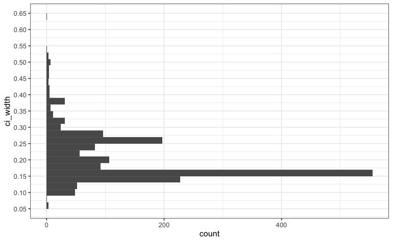

```r
bayesian_data %>%
  ggplot(aes(y = ci_width)) +
  geom_histogram() +
    scale_y_continuous(breaks = scales::pretty_breaks(n = 10)) +
    theme_bw()
```

Create credible interval width “bins” `ci_width_bin`

### All pairwise comparisons (bins)

```r
kable(bayesian_data %>%
  tabyl(ci_width_bin) %>% adorn_totals("row"),
  caption = "The proportion of pairwise comparisons with each CI width bin") %>%
kable_styling(position = "left", bootstrap_options = c("striped", "hover")) %>%
  scroll_box(width = "100%", height = "400px")
```

The proportion of pairwise comparisons with each CI width bin

| ci_width_bin | n | percent |
| --- | --- | --- |
| (0,0.1] | 14 | 0.0084694 |
| (0.1,0.2] | 1041 | 0.6297641 |
| (0.2,0.3] | 480 | 0.2903811 |
| (0.3,0.4] | 87 | 0.0526316 |
| (0.4,0.5] | 21 | 0.0127042 |
| (0.5,0.6] | 9 | 0.0054446 |
| (0.6,0.7] | 1 | 0.0006050 |
| Total | 1653 | 1.0000000 |

```
Ignoring unknown parameters: binwidth, bins, pad
```

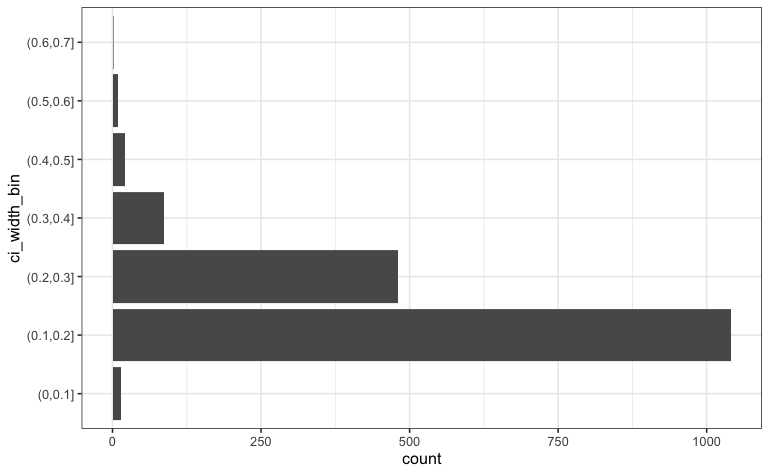

```r
bayesian_data %>%
  ggplot(aes(y = ci_width_bin)) +
    geom_histogram(stat = "count") +
    theme_bw()
```

### Within *var*code

#### Summary stats all comparisons

Out of the 668 within-varcode pairwise comparisons, 36 pairwise comparisons had a large credible interval width (0.2-0.4), indicating higher uncertainty in these estimates. 36 (100%) of these more uncertain pairwise comparisons involved pairwise comparisons to the two *P. falciparum* isolates with the smallest repertoire sizes (11 and 19 types).

```r
kable(bayesian_data %>% filter(comparison %in% within_comp) %>%
        summarise(min = min(ci_width),
                  med = median(ci_width),
                  mean = mean(ci_width),
                  max = max(ci_width)),
      caption = "Summary statistics for credible interval width:") %>%
  kable_styling(position = "left", bootstrap_options = c("striped", "hover")) %>%
  scroll_box(width = "100%")
```

Summary statistics for credible interval width:

| min | med | mean | max |
| --- | --- | --- | --- |
| 0.1041667 | 0.16 | 0.1641741 | 0.3125 |

```r
kable(bayesian_data %>%
  filter(comparison %in% within_comp) %>%
  tabyl(ci_width_bin) %>%
  adorn_totals("row"),
  caption = "The proportion of within-varcode pairwise comparisons with each CI width bin:") %>%
kable_styling(position = "left", bootstrap_options = c("striped", "hover")) %>%
  scroll_box(width = "100%", height = "400px")
```

The proportion of within-varcode pairwise comparisons with each CI width bin:

| ci_width_bin | n | percent |
| --- | --- | --- |
| (0,0.1] | 0 | 0.0000000 |
| (0.1,0.2] | 632 | 0.9461078 |
| (0.2,0.3] | 32 | 0.0479042 |
| (0.3,0.4] | 4 | 0.0059880 |
| (0.4,0.5] | 0 | 0.0000000 |
| (0.5,0.6] | 0 | 0.0000000 |
| (0.6,0.7] | 0 | 0.0000000 |
| Total | 668 | 1.0000000 |

```r
total_withinvc_comparisons <- bayesian_data %>% filter(comparison %in% within_comp) %>% nrow()
```

```r
total_withinvc_uncertain <- bayesian_data %>% filter(comparison %in% within_comp) %>% filter(ci_width_bin == "(0.2,0.3]" | ci_width_bin == "(0.3,0.4]") %>% nrow()

bayesian_data %>%
  filter(comparison %in% within_comp) %>%
  filter(ci_width_bin == "(0.2,0.3]") %>%
  filter(SampleID1 == "ECPf004" | SampleID2 == "ECPf004" | SampleID1 == "ECPf011" | SampleID2 == "ECPf011") %>%
  select(SampleID1, SampleID2, comparison, ci_width, ci_width_bin)

32/32 #the number of uncertain pairwise comparisons involving ECPf004 or ECPf011

bayesian_data %>%
  filter(comparison %in% within_comp) %>%
  filter(ci_width_bin == "(0.3,0.4]") %>%
  filter(SampleID1 == "ECPf004" | SampleID2 == "ECPf004" | SampleID1 == "ECPf011" | SampleID2 == "ECPf011") %>%
  select(SampleID1, SampleID2, comparison, ci_width, ci_width_bin)

4/4 #the number of uncertain pairwise comparisons involving ECPf004 or ECPf011
```

#### Summary stats by comparison

```r
kable(bayesian_data %>%
  filter(comparison %in% within_comp) %>%
  select(SampleID1, SampleID2, comparison, ci_width, ci_width_bin) %>%
  tabyl(comparison, ci_width_bin) %>%
  adorn_totals("col") %>%
  adorn_percentages("row") %>%
  adorn_pct_formatting(digits = 1) %>%
  adorn_ns("front")) %>%
  kable_styling(position = "left", full_width = F, bootstrap_options = c("striped", "hover")) %>%
  scroll_box(width = "100%", height = "400px")
```

| comparison | (0,0.1] | (0.1,0.2] | (0.2,0.3] | (0.3,0.4] | (0.4,0.5] | (0.5,0.6] | (0.6,0.7] | Total |
| --- | --- | --- | --- | --- | --- | --- | --- | --- |
| varcode1 vs varcode1 | 0 (0.0%) | 594 (94.3%) | 32 (5.1%) | 4 (0.6%) | 0 (0.0%) | 0 (0.0%) | 0 (0.0%) | 630 (100.0%) |
| varcode2 vs varcode2 | 0 (0.0%) | 3 (100.0%) | 0 (0.0%) | 0 (0.0%) | 0 (0.0%) | 0 (0.0%) | 0 (0.0%) | 3 (100.0%) |
| varcode3 vs varcode3 | 0 (0.0%) | 3 (100.0%) | 0 (0.0%) | 0 (0.0%) | 0 (0.0%) | 0 (0.0%) | 0 (0.0%) | 3 (100.0%) |
| varcode6 vs varcode6 | 0 (0.0%) | 3 (100.0%) | 0 (0.0%) | 0 (0.0%) | 0 (0.0%) | 0 (0.0%) | 0 (0.0%) | 3 (100.0%) |
| varcode7 vs varcode7 | 0 (0.0%) | 28 (100.0%) | 0 (0.0%) | 0 (0.0%) | 0 (0.0%) | 0 (0.0%) | 0 (0.0%) | 28 (100.0%) |
| varcode8 vs varcode8 | 0 (0.0%) | 1 (100.0%) | 0 (0.0%) | 0 (0.0%) | 0 (0.0%) | 0 (0.0%) | 0 (0.0%) | 1 (100.0%) |

#### Counts

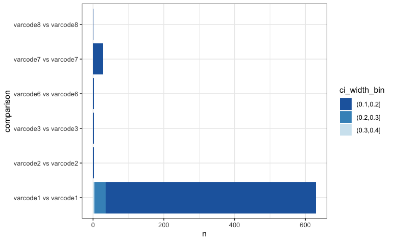

```r
bayesian_data %>%
  filter(comparison %in% within_comp) %>%
  group_by(comparison, ci_width_bin) %>%
  tally() %>%
  ggplot(aes(x = n, y = comparison, fill = ci_width_bin)) +
    geom_bar(stat = "identity") +
    scale_fill_manual(values = c("#2166ac", "#4393c3", "#d1e5f0", "#f4a582", "#ca0020")) +
    theme_bw()
```

```r
within_varcode_ci_counts <- bayesian_data %>%
  filter(comparison %in% within_comp) %>%
  group_by(comparison, ci_width_bin) %>%
  tally() %>%
  ggplot(aes(x = n, y = comparison, fill = ci_width_bin)) +
    geom_bar(stat = "identity") +
    scale_fill_manual(values = c("#2166ac", "#4393c3", "#d1e5f0", "#f4a582", "#ca0020")) +
    labs(x = "Number of pairwise comparisons",
         y = "",
         fill = "credible interval \nwidth bin") +
    theme_bw()
```

#### Proportions

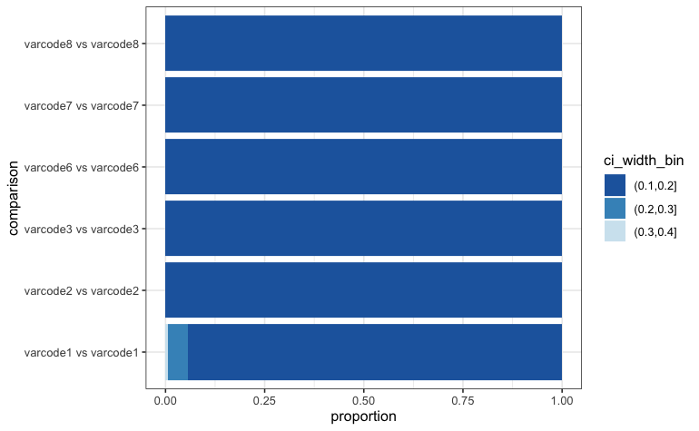

```r
bayesian_data %>%
  filter(comparison %in% within_comp) %>%
  group_by(comparison, ci_width_bin) %>%
  tally() %>%
  ggplot(aes(x = n, y = comparison, fill = ci_width_bin)) +
    geom_bar(stat = "identity", position = "fill") +
    scale_fill_manual(values = c("#2166ac", "#4393c3", "#d1e5f0", "#f4a582", "#ca0020")) +
    labs(x = "proportion") +
    theme_bw()
```

```r
within_varcode_ci_props <- bayesian_data %>%
  filter(comparison %in% within_comp) %>%
  group_by(comparison, ci_width_bin) %>%
  tally() %>%
  ggplot(aes(x = n, y = comparison, fill = ci_width_bin)) +
    geom_bar(stat = "identity", position = "fill") +
    scale_y_discrete(labels = c("varcode1 vs varcode1 \n(n=630)",
                                "varcode2 vs varcode2 \n (n=3)",
                                "varcode3 vs varcode3 \n (n=3)",
                                "varcode6 vs varcode6 \n (n=3)",
                                "varcode7 vs varcode7 \n (n=28)",
                                "varcode8 vs varcode8 \n (n=1)")) +
    scale_fill_manual(values = c("#2166ac", "#4393c3", "#d1e5f0", "#f4a582", "#ca0020")) +
    labs(x = "Proportion of pairwise comparisons",
         y = "",
         fill = "Credible interval \nwidth bin") +
    theme_bw()
```

### Between *var*code

#### Summary stats all comparisons

```r
kable(bayesian_data %>% filter(comparison %in% between_comp) %>%
        summarise(min = min(ci_width),
                  med = median(ci_width),
                  mean = mean(ci_width),
                  max = max(ci_width)),
      caption = "Summary statistics for credible interval width:") %>%
  kable_styling(position = "left")
```

Summary statistics for credible interval width:

| min | med | mean | max |
| --- | --- | --- | --- |
| 0.0633333 | 0.2202381 | 0.2246911 | 0.6428571 |

```r
kable(bayesian_data %>%
  filter(comparison %in% between_comp) %>%
  tabyl(ci_width_bin) %>%
  adorn_totals("row"),
  caption = "The proportion of between-varcode pairwise comparisons with each CI width bin") %>%
kable_styling(position = "left", bootstrap_options = c("striped", "hover")) %>%
  scroll_box(width = "100%", height = "400px")
```

The proportion of between-varcode pairwise comparisons with each CI width bin

| ci_width_bin | n | percent |
| --- | --- | --- |
| (0,0.1] | 14 | 0.0142132 |
| (0.1,0.2] | 409 | 0.4152284 |
| (0.2,0.3] | 448 | 0.4548223 |
| (0.3,0.4] | 83 | 0.0842640 |
| (0.4,0.5] | 21 | 0.0213198 |
| (0.5,0.6] | 9 | 0.0091371 |
| (0.6,0.7] | 1 | 0.0010152 |
| Total | 985 | 1.0000000 |

```r
total_betweenvc_comparisons <- bayesian_data %>% filter(comparison %in% between_comp) %>% nrow()
```

#### Summary stats by comparison

```r
kable(bayesian_data %>%
  filter(comparison %in% between_comp) %>%
  select(SampleID1, SampleID2, comparison, ci_width, ci_width_bin) %>%
  tabyl(comparison, ci_width_bin) %>%
  adorn_totals("col") %>%
  adorn_percentages("row") %>%
  adorn_pct_formatting(digits = 1) %>%
  adorn_ns("front")) %>%
  kable_styling(position = "left", full_width = F, bootstrap_options = c("striped", "hover")) %>%
  scroll_box(width = "100%", height = "400px")
```

| comparison | (0,0.1] | (0.1,0.2] | (0.2,0.3] | (0.3,0.4] | (0.4,0.5] | (0.5,0.6] | (0.6,0.7] | Total |
| --- | --- | --- | --- | --- | --- | --- | --- | --- |
| varcode1 vs varcode2 | 0 (0.0%) | 99 (91.7%) | 3 (2.8%) | 3 (2.8%) | 3 (2.8%) | 0 (0.0%) | 0 (0.0%) | 108 (100.0%) |
| varcode1 vs varcode3 | 0 (0.0%) | 0 (0.0%) | 66 (61.1%) | 38 (35.2%) | 1 (0.9%) | 2 (1.9%) | 1 (0.9%) | 108 (100.0%) |
| varcode1 vs varcode4 | 0 (0.0%) | 4 (11.1%) | 30 (83.3%) | 1 (2.8%) | 0 (0.0%) | 1 (2.8%) | 0 (0.0%) | 36 (100.0%) |
| varcode1 vs varcode5 | 6 (16.7%) | 28 (77.8%) | 1 (2.8%) | 1 (2.8%) | 0 (0.0%) | 0 (0.0%) | 0 (0.0%) | 36 (100.0%) |
| varcode1 vs varcode6 | 0 (0.0%) | 68 (63.0%) | 34 (31.5%) | 3 (2.8%) | 0 (0.0%) | 3 (2.8%) | 0 (0.0%) | 108 (100.0%) |
| varcode1 vs varcode7 | 0 (0.0%) | 0 (0.0%) | 245 (85.1%) | 27 (9.4%) | 13 (4.5%) | 3 (1.0%) | 0 (0.0%) | 288 (100.0%) |
| varcode1 vs varcode8 | 0 (0.0%) | 68 (94.4%) | 2 (2.8%) | 1 (1.4%) | 1 (1.4%) | 0 (0.0%) | 0 (0.0%) | 72 (100.0%) |
| varcode1 vs varcode9 | 0 (0.0%) | 6 (16.7%) | 28 (77.8%) | 0 (0.0%) | 2 (5.6%) | 0 (0.0%) | 0 (0.0%) | 36 (100.0%) |
| varcode2 vs varcode3 | 0 (0.0%) | 6 (66.7%) | 3 (33.3%) | 0 (0.0%) | 0 (0.0%) | 0 (0.0%) | 0 (0.0%) | 9 (100.0%) |
| varcode2 vs varcode4 | 0 (0.0%) | 3 (100.0%) | 0 (0.0%) | 0 (0.0%) | 0 (0.0%) | 0 (0.0%) | 0 (0.0%) | 3 (100.0%) |
| varcode2 vs varcode5 | 0 (0.0%) | 3 (100.0%) | 0 (0.0%) | 0 (0.0%) | 0 (0.0%) | 0 (0.0%) | 0 (0.0%) | 3 (100.0%) |
| varcode2 vs varcode6 | 0 (0.0%) | 9 (100.0%) | 0 (0.0%) | 0 (0.0%) | 0 (0.0%) | 0 (0.0%) | 0 (0.0%) | 9 (100.0%) |
| varcode2 vs varcode7 | 0 (0.0%) | 24 (100.0%) | 0 (0.0%) | 0 (0.0%) | 0 (0.0%) | 0 (0.0%) | 0 (0.0%) | 24 (100.0%) |
| varcode2 vs varcode8 | 0 (0.0%) | 6 (100.0%) | 0 (0.0%) | 0 (0.0%) | 0 (0.0%) | 0 (0.0%) | 0 (0.0%) | 6 (100.0%) |
| varcode2 vs varcode9 | 0 (0.0%) | 3 (100.0%) | 0 (0.0%) | 0 (0.0%) | 0 (0.0%) | 0 (0.0%) | 0 (0.0%) | 3 (100.0%) |
| varcode3 vs varcode4 | 0 (0.0%) | 2 (66.7%) | 0 (0.0%) | 1 (33.3%) | 0 (0.0%) | 0 (0.0%) | 0 (0.0%) | 3 (100.0%) |
| varcode3 vs varcode5 | 1 (33.3%) | 2 (66.7%) | 0 (0.0%) | 0 (0.0%) | 0 (0.0%) | 0 (0.0%) | 0 (0.0%) | 3 (100.0%) |
| varcode3 vs varcode6 | 0 (0.0%) | 6 (66.7%) | 3 (33.3%) | 0 (0.0%) | 0 (0.0%) | 0 (0.0%) | 0 (0.0%) | 9 (100.0%) |
| varcode3 vs varcode7 | 0 (0.0%) | 0 (0.0%) | 16 (66.7%) | 7 (29.2%) | 1 (4.2%) | 0 (0.0%) | 0 (0.0%) | 24 (100.0%) |
| varcode3 vs varcode8 | 0 (0.0%) | 4 (66.7%) | 2 (33.3%) | 0 (0.0%) | 0 (0.0%) | 0 (0.0%) | 0 (0.0%) | 6 (100.0%) |
| varcode3 vs varcode9 | 0 (0.0%) | 1 (33.3%) | 1 (33.3%) | 1 (33.3%) | 0 (0.0%) | 0 (0.0%) | 0 (0.0%) | 3 (100.0%) |
| varcode4 vs varcode5 | 1 (100.0%) | 0 (0.0%) | 0 (0.0%) | 0 (0.0%) | 0 (0.0%) | 0 (0.0%) | 0 (0.0%) | 1 (100.0%) |
| varcode4 vs varcode6 | 0 (0.0%) | 3 (100.0%) | 0 (0.0%) | 0 (0.0%) | 0 (0.0%) | 0 (0.0%) | 0 (0.0%) | 3 (100.0%) |
| varcode4 vs varcode7 | 0 (0.0%) | 6 (75.0%) | 2 (25.0%) | 0 (0.0%) | 0 (0.0%) | 0 (0.0%) | 0 (0.0%) | 8 (100.0%) |
| varcode4 vs varcode8 | 2 (100.0%) | 0 (0.0%) | 0 (0.0%) | 0 (0.0%) | 0 (0.0%) | 0 (0.0%) | 0 (0.0%) | 2 (100.0%) |
| varcode4 vs varcode9 | 0 (0.0%) | 1 (100.0%) | 0 (0.0%) | 0 (0.0%) | 0 (0.0%) | 0 (0.0%) | 0 (0.0%) | 1 (100.0%) |
| varcode5 vs varcode6 | 3 (100.0%) | 0 (0.0%) | 0 (0.0%) | 0 (0.0%) | 0 (0.0%) | 0 (0.0%) | 0 (0.0%) | 3 (100.0%) |
| varcode5 vs varcode7 | 1 (12.5%) | 7 (87.5%) | 0 (0.0%) | 0 (0.0%) | 0 (0.0%) | 0 (0.0%) | 0 (0.0%) | 8 (100.0%) |
| varcode5 vs varcode8 | 0 (0.0%) | 2 (100.0%) | 0 (0.0%) | 0 (0.0%) | 0 (0.0%) | 0 (0.0%) | 0 (0.0%) | 2 (100.0%) |
| varcode5 vs varcode9 | 0 (0.0%) | 0 (0.0%) | 1 (100.0%) | 0 (0.0%) | 0 (0.0%) | 0 (0.0%) | 0 (0.0%) | 1 (100.0%) |
| varcode6 vs varcode7 | 0 (0.0%) | 14 (58.3%) | 10 (41.7%) | 0 (0.0%) | 0 (0.0%) | 0 (0.0%) | 0 (0.0%) | 24 (100.0%) |
| varcode6 vs varcode8 | 0 (0.0%) | 6 (100.0%) | 0 (0.0%) | 0 (0.0%) | 0 (0.0%) | 0 (0.0%) | 0 (0.0%) | 6 (100.0%) |
| varcode6 vs varcode9 | 0 (0.0%) | 3 (100.0%) | 0 (0.0%) | 0 (0.0%) | 0 (0.0%) | 0 (0.0%) | 0 (0.0%) | 3 (100.0%) |
| varcode7 vs varcode8 | 0 (0.0%) | 16 (100.0%) | 0 (0.0%) | 0 (0.0%) | 0 (0.0%) | 0 (0.0%) | 0 (0.0%) | 16 (100.0%) |
| varcode7 vs varcode9 | 0 (0.0%) | 8 (100.0%) | 0 (0.0%) | 0 (0.0%) | 0 (0.0%) | 0 (0.0%) | 0 (0.0%) | 8 (100.0%) |
| varcode8 vs varcode9 | 0 (0.0%) | 1 (50.0%) | 1 (50.0%) | 0 (0.0%) | 0 (0.0%) | 0 (0.0%) | 0 (0.0%) | 2 (100.0%) |

#### Counts

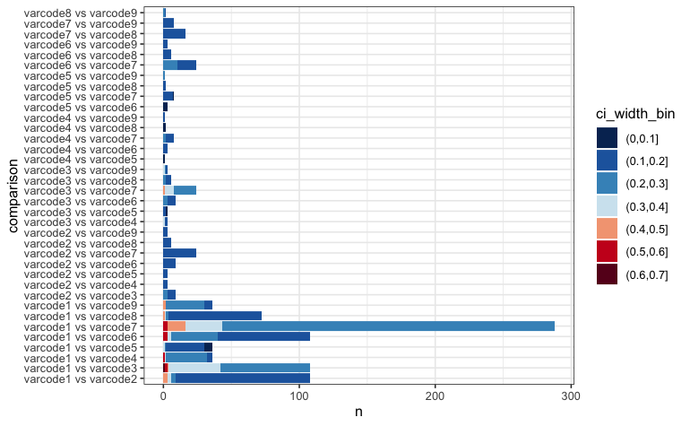

```r
bayesian_data %>%
  filter(comparison %in% between_comp) %>%
  group_by(comparison, ci_width_bin) %>%
  tally() %>%
  ggplot(aes(x = n, y = comparison, fill = ci_width_bin)) +
    geom_bar(stat = "identity") +
    scale_fill_manual(values = c("#053061", "#2166ac", "#4393c3", "#d1e5f0", "#f4a582", "#ca0020", "#67001f")) +
    theme_bw()
```

```r
between_varcode_ci_counts <- bayesian_data %>%
  filter(comparison %in% between_comp) %>%
  group_by(comparison, ci_width_bin) %>%
  tally() %>%
  ggplot(aes(x = n, y = comparison, fill = ci_width_bin)) +
    geom_bar(stat = "identity") +
    scale_fill_manual(values = c("#053061", "#2166ac", "#4393c3", "#d1e5f0", "#f4a582", "#ca0020", "#67001f")) +
    labs(x = "Number of pairwise comparisons",
         y = "",
         fill = "Credible interval \nwidth bin") +
    theme_bw()
```

#### Proportion

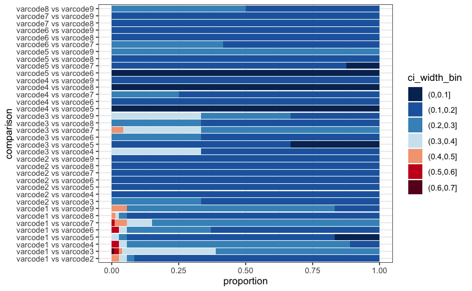

```r
bayesian_data %>%
  filter(comparison %in% between_comp) %>%
  group_by(comparison, ci_width_bin) %>%
  tally() %>%
  ggplot(aes(x = n, y = comparison, fill = ci_width_bin)) +
    geom_bar(stat = "identity", position = "fill") +
    scale_fill_manual(values = c("#053061", "#2166ac", "#4393c3", "#d1e5f0", "#f4a582", "#ca0020", "#67001f")) +
    labs(x = "proportion") +
    theme_bw()
```

```r
between_varcode_ci_props <- bayesian_data %>%
  filter(comparison %in% between_comp) %>%
  group_by(comparison, ci_width_bin) %>%
  tally() %>%
  ggplot(aes(x = n, y = comparison, fill = ci_width_bin)) +
    geom_bar(stat = "identity", position = "fill") +
    scale_fill_manual(values = c("#053061", "#2166ac", "#4393c3", "#d1e5f0", "#f4a582", "#ca0020", "#67001f")) +
    labs(x = "Proportion of pairwise comparisons",
         y = "",
         fill = "Credible interval \nwidth bin") +
    theme_bw()
```

## Differences between observed and estimated mean PTS

```r
bayesian_data %>%
  mutate(diff = GS_score - xa_mean) %>% summarise(min = min(diff),
                                                  med = median(diff),
                                                  mean = mean(diff),
                                                  max = max(diff))
```

| min | med | mean | max |
| --- | --- | --- | --- |
| -0.6320662 | -0.04900326 | -0.08278423 | 0.06505965 |

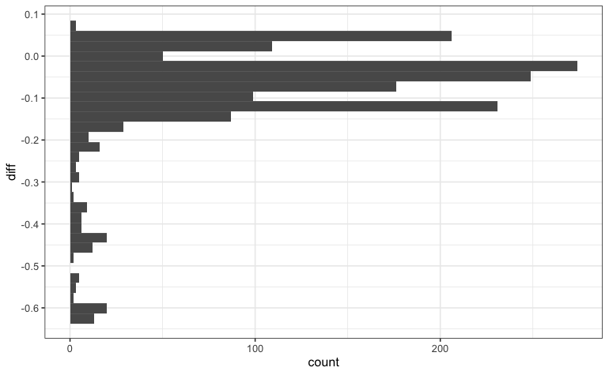

```r
bayesian_data %>%
  mutate(diff = GS_score - xa_mean) %>%
  ggplot(aes(y = diff)) +
    geom_histogram() +
    scale_y_continuous(breaks = scales::pretty_breaks(n = 10)) +
    theme_bw()
```

### Correlation between PTS and mean bayesian PTS (s/Ra)

```
Tried to calculate with group_by(), but the calculation failed.
Falling back to ungrouped filter operation...label_key: outlier_isos
Too many data points, skip labeling
```

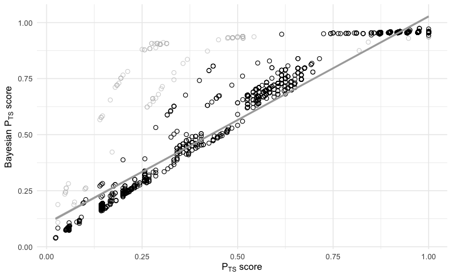

```r
bayesian_data %>%
    ggplot(aes(x = GS_score, y = xa_mean)) +
    geom_point(aes(group = outlier_isos), shape = 21, size = 2) +
    scale_color_manual(values = c("black", "#ef8a62"),
                       name = "") +
    gghighlight::gghighlight(outlier_isos %in% "not outlier isolates") +
    geom_smooth(method = "lm", se = T, formula = "y ~ x", color = "darkgrey") +
    scale_y_continuous(breaks = seq(0, 1, by = 0.25)) +
    ylab(expression(paste("Bayesian P"["TS"], " score"))) +
    xlab(expression(paste("P"["TS"], " score"))) +
    theme_minimal()
```

### Correlation between PTS and mean bayesian PTS (s/Ra) vs microsatellite PAS

```r
bayesian_data <- bayesian_data %>% left_join(PAStable_ecuMS, by = c("SampleID1", "SampleID2"))
bayesian_data <- bayesian_data %>% rename_at("GS_score.x", ~"GS_score") %>%
                                   rename_at("GS_score.y", ~"PAS_score")

corr_bayesian_microsat <- bayesian_data %>%
   ggplot(aes(x = xa_mean, y = PAS_score)) +
      geom_jitter(shape = 21, color = "black", size = 2) +
      geom_smooth(method = "lm", se = T, color = "darkgrey") +
      scale_y_continuous(breaks = seq(0, 1, by = 0.25)) +
      theme_cowplot() +
      ylab(expression(paste("P"["AS"], " score"))) +
      xlab(expression(paste("Bayesian P"["TS"], " score"))) +
      background_grid(major = "xy", minor = "none")

cor.test(bayesian_data$xa_mean, bayesian_data$PAS_score, method = c("pearson"))
```

```
    Pearson's product-moment correlation

data:  bayesian_data$xa_mean and bayesian_data$PAS_score
t = 50.544, df = 1651, p-value < 2.2e-16
alternative hypothesis: true correlation is not equal to 0
95 percent confidence interval:
 0.7597194 0.7976263
sample estimates:
     cor
0.779385
```

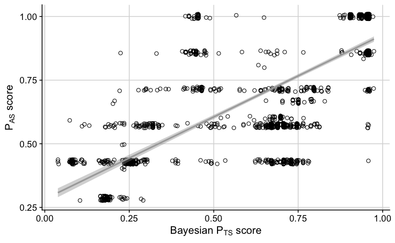

```r
plot_supp_correlation <- correlation_plot + corr_bayesian_microsat + plot_annotation(tag_levels = "a")
save_plot("viz/supp_correlation_PTSvPASvBayesian.png", plot_supp_correlation, base_width = 12, base_height = 6)
corr_bayesian_microsat
```

There were a total of 31 (6%) out of 541 pairwise comparisons where PAS=1 but bayesian PTS ≤0.50.

There were a total of 196 (16%) out of 1232 pairwise comparisons where PAS>0.50 but bayesian PTS ≤0.50.

## Within-varcode bayesian PTS (s/Ra)

### PTS lower cut-off value

*note: circles in light red correspond to pairwise comparisons involving the isolates with the smallest repertoire sizes, many of which had higher uncertainty*

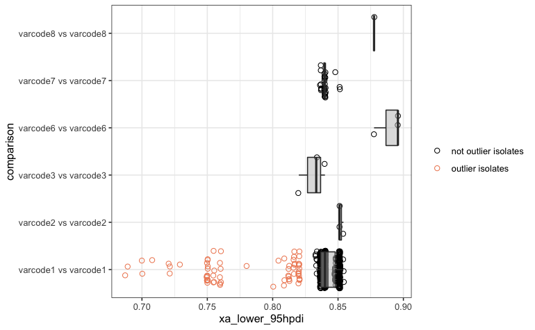

```r
bayesian_data %>%
  filter(comparison %in% within_comp) %>%
  ggplot(aes(x = xa_lower_95hpdi, y = comparison)) +
    geom_jitter(aes(color = outlier_isos), shape = 21, size = 2) +
  scale_color_manual(values = c("black", "#ef8a62"),
                       name = "") +
    geom_boxplot(fill = "grey", alpha = 0.5, outlier.shape = NA) +
    theme_bw()
```

### mean PTS

*note: circles in light red correspond to pairwise comparisons involving the isolates with the smallest repertoire sizes, many of which had higher uncertainty*

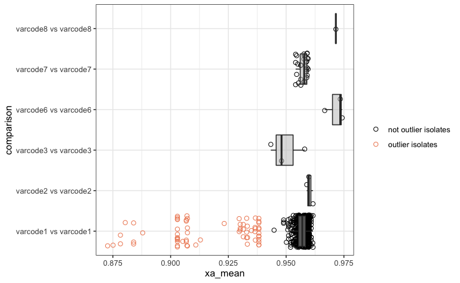

### PTS upper cut-off value

*note: circles in light red correspond to pairwise comparisons involving the isolates with the smallest repertoire sizes, many of which had higher uncertainty*

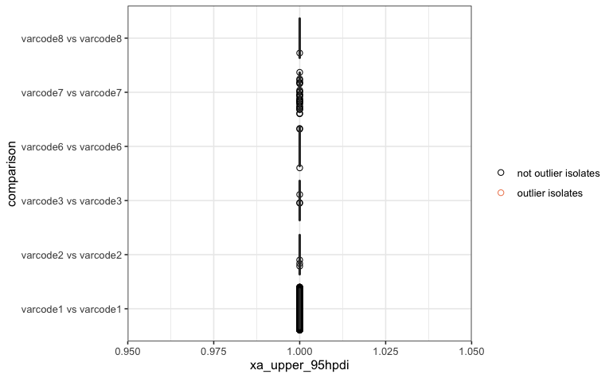

## Between-varcode bayesian PTS (s/Ra)

### PTS lower-cutoff

*note: circles in light red correspond to pairwise comparisons involving the isolates with the smallest repertoire sizes, many of which had higher uncertainty*

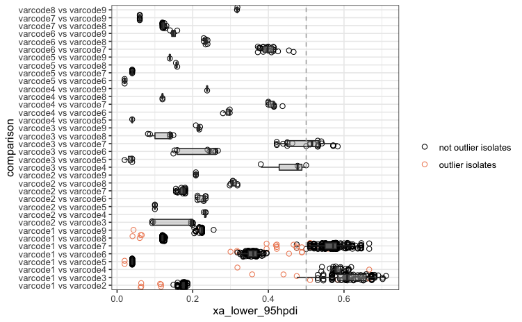

### mean PTS

*note: circles in light red correspond to pairwise comparisons involving the isolates with the smallest repertoire sizes, many of which had higher uncertainty*

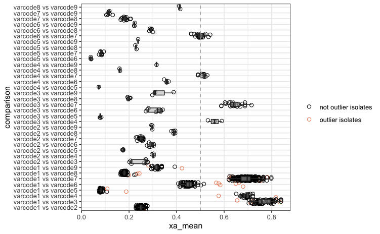

### PTS upper cut-off

*note: circles in light red correspond to pairwise comparisons involving the isolates with the smallest repertoire sizes, many of which had higher uncertainty*

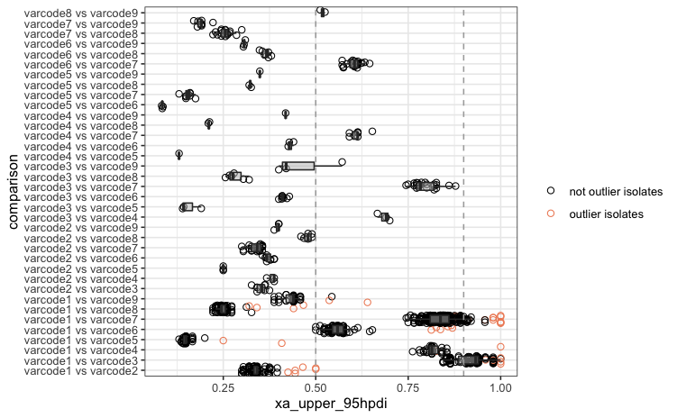

## Observed PTS

### Within-varcode observed PTS

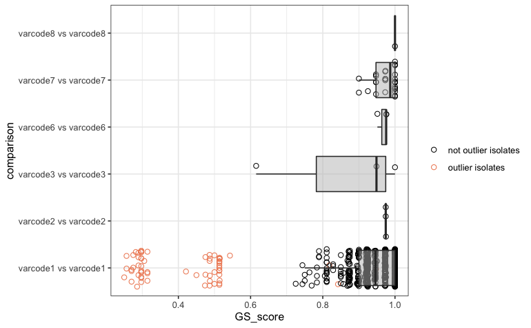

### Between-varcode observed PTS

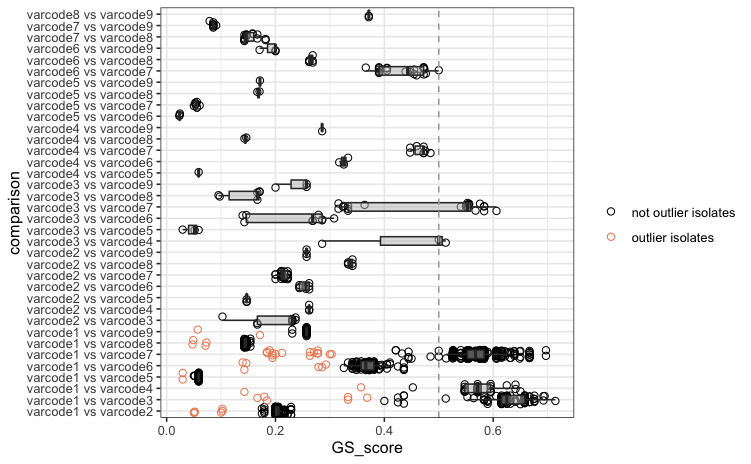

## Networks bayesian mean PTS i.e. s/Ra

### s/Ra ≥0.90

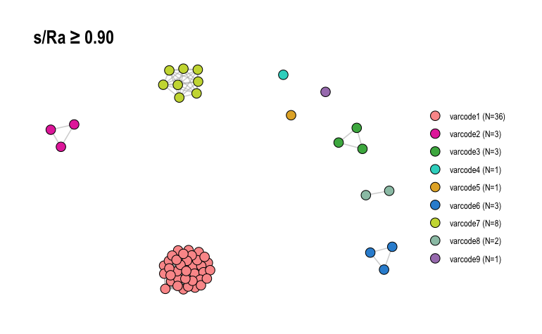

```r
bayesian_edges <- bayesian_data %>% select(id1, id2, xa_mean)
bayesian_tidy <- tbl_graph(nodes = ecu_epi, edges = bayesian_edges, directed = T)

# varcode_list <- ecu_epi %>% select(SampleID, varcode)
# varcode_list$SampleID <- as.factor(varcode_list$SampleID)
# varcode_list$varcode <- as.factor(varcode_list$varcode)
# varcode_list <- varcode_list %>% column_to_rownames("SampleID")
# varcode_colors <- list(varcode = c("varcode1" = "#fb9a99", "varcode2" = "#e538a9","varcode3" = "#48B24F", "varcode4" = "#30d5c8", "varcode5" = "#E4B031", "varcode6" = "#3090d5", "varcode7" = "#CAD93F", "varcode8" = "#9ac4b3", "varcode9" = "#a880bb"))

bayesian_tidy %>% activate(edges) %>% filter(xa_mean >= 0.90) %>%
  ggraph(layout = "fr") +
  geom_edge_link(color = "darkgrey", alpha = 0.5) +
  geom_node_point(aes(fill = varcode), shape = 21, color = "black", size = 4) +
  #geom_node_text(aes(label = SampleID), repel = TRUE) +
  labs(edge_width = "SampleID",
       fill = "") +
  scale_fill_manual(values = varcode_colors$varcode, labels = c("varcode1 (N=36)", "varcode2 (N=3)", "varcode3 (N=3)", "varcode4 (N=1)", "varcode5 (N=1)", "varcode6 (N=3)", "varcode7 (N=8)", "varcode8 (N=2)", "varcode9 (N=1)")) +
  labs(title = "s/Ra ≥ 0.90") +
  theme_graph()

varcodes_bayesian_network <- bayesian_tidy %>% activate(edges) %>% filter(xa_mean >= 0.90) %>%
  ggraph(layout = "fr") +
  geom_edge_link(color = "darkgrey", alpha = 0.5) +
  geom_node_point(aes(fill = varcode), shape = 21, color = "black", size = 4) +
  #geom_node_text(aes(label = SampleID), repel = TRUE) +
  labs(edge_width = "SampleID",
       fill = "") +
  scale_fill_manual(values = varcode_colors$varcode, labels = c("varcode1 (N=36)", "varcode2 (N=3)", "varcode3 (N=3)", "varcode4 (N=1)", "varcode5 (N=1)", "varcode6 (N=3)", "varcode7 (N=8)", "varcode8 (N=2)", "varcode9 (N=1)")) +
  #labs(title = "s/Ra ≥ 0.90") +
  theme_graph()

save_plot("viz/varcode_bayesian_network.png", varcodes_bayesian_network, base_width = 8, base_height = 6)
```

### s/Ra ≥0.50

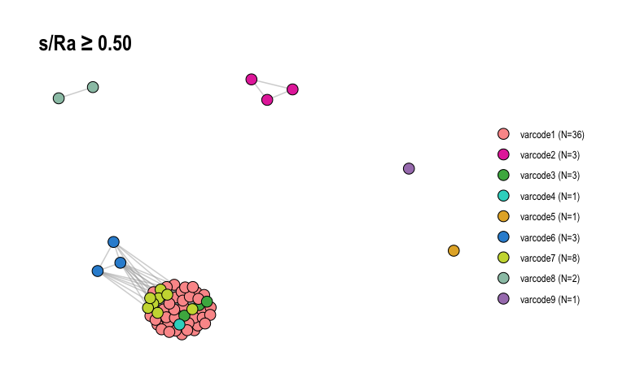

```r
bayesian_tidy %>% activate(edges) %>% filter(xa_mean >= 0.50) %>%
  ggraph(layout = "fr") +
  geom_edge_link(color = "darkgrey", alpha = 0.5) +
  geom_node_point(aes(fill = varcode), shape = 21, color = "black", size = 4) +
  #geom_node_text(aes(label = SampleID), repel = TRUE) +
  labs(edge_width = "SampleID",
       fill = "") +
  scale_fill_manual(values = varcode_colors$varcode, labels = c("varcode1 (N=36)", "varcode2 (N=3)", "varcode3 (N=3)", "varcode4 (N=1)", "varcode5 (N=1)", "varcode6 (N=3)", "varcode7 (N=8)", "varcode8 (N=2)", "varcode9 (N=1)")) +
  labs(title = "s/Ra ≥ 0.50") +
  theme_graph()

recombinants_bayesian_network <- bayesian_tidy %>% activate(edges) %>% filter(xa_mean >= 0.50) %>%
  ggraph(layout = "fr") +
  geom_edge_link(color = "darkgrey", alpha = 0.5) +
  geom_node_point(aes(fill = varcode), shape = 21, color = "black", size = 4) +
  #geom_node_text(aes(label = SampleID), repel = TRUE) +
  labs(edge_width = "SampleID",
       fill = "") +
  scale_fill_manual(values = varcode_colors$varcode, labels = c("varcode1 (N=36)", "varcode2 (N=3)", "varcode3 (N=3)", "varcode4 (N=1)", "varcode5 (N=1)", "varcode6 (N=3)", "varcode7 (N=8)", "varcode8 (N=2)", "varcode9 (N=1)")) +
  #labs(title = "s/Ra ≥ 0.50") +
  theme_graph()

save_plot("viz/recombinants_bayesian_network.png", recombinants_bayesian_network, base_width = 8, base_height = 6)
```

## High-confidence pairwise comparisons

For our networks at PTS or BPTS ≥0.50, we calculate the proportion of pairwise comparisons that are high-confidence. For recombinants (PTS or BPTS ≥0.50), we calculate the proportion of pairwise comparisons where the *lower* bound of the 95% HDPI is confidently *above* the threshold of ≥0.50 (we found 70.9%, N=433/611). For genetically-distinct *var*codes (PTS or BPTS ≤0.50), we calculate the proportion of pairwise comparisons where the *upper* bound of the 95% HDPI is confidently *below* the threshold of ≤0.50 (we found 98.4%, N=368/374).

```r
#total recombinant pw comparisons
total_recomb_pw_comp <- bayesian_data %>%
  filter(comparison %in% between_comp) %>%
  filter(comparison == "varcode1 vs varcode3" |
           comparison == "varcode1 vs varcode4" |
           comparison == "varcode1 vs varcode6" |
           comparison == "varcode1 vs varcode7" |
           comparison == "varcode3 vs varcode4" |
           comparison == "varcode3 vs varcode6" |
           comparison == "varcode3 vs varcode7" |
           comparison == "varcode4 vs varcode6" |
           comparison == "varcode4 vs varcode7" |
           comparison == "varcode6 vs varcode7") %>% nrow()
highconf_recomb_pw_comp <- bayesian_data %>%
  filter(comparison %in% between_comp) %>%
  filter(comparison == "varcode1 vs varcode3" |
           comparison == "varcode1 vs varcode4" |
           comparison == "varcode1 vs varcode6" |
           comparison == "varcode1 vs varcode7" |
           comparison == "varcode3 vs varcode4" |
           comparison == "varcode3 vs varcode6" |
           comparison == "varcode3 vs varcode7" |
           comparison == "varcode4 vs varcode6" |
           comparison == "varcode4 vs varcode7" |
           comparison == "varcode6 vs varcode7") %>%
  filter(xa_lower_95hpdi >= 0.50) %>%
  nrow()

highconf_recomb_pw_comp/total_recomb_pw_comp

total_distinct_pw_comp <- bayesian_data %>% #posterior mean
  filter(comparison %in% between_comp) %>%
  filter(comparison != "varcode1 vs varcode3",
         comparison != "varcode1 vs varcode4",
         comparison != "varcode1 vs varcode6",
         comparison != "varcode1 vs varcode7",
         comparison != "varcode3 vs varcode4",
         comparison != "varcode3 vs varcode6",
         comparison != "varcode3 vs varcode7",
         comparison != "varcode4 vs varcode6",
         comparison != "varcode4 vs varcode7",
         comparison != "varcode6 vs varcode7") %>% nrow()

highconf_distinct_pw_comp <- bayesian_data %>% #posterior mean
  filter(comparison %in% between_comp) %>%
  filter(comparison != "varcode1 vs varcode3",
         comparison != "varcode1 vs varcode4",
         comparison != "varcode1 vs varcode6",
         comparison != "varcode1 vs varcode7",
         comparison != "varcode3 vs varcode4",
         comparison != "varcode3 vs varcode6",
         comparison != "varcode3 vs varcode7",
         comparison != "varcode4 vs varcode6",
         comparison != "varcode4 vs varcode7",
         comparison != "varcode6 vs varcode7") %>%
  filter(xa_upper_95hpdi <= 0.50) %>% nrow()

highconf_distinct_pw_comp/total_distinct_pw_comp
```

## Figures for paper

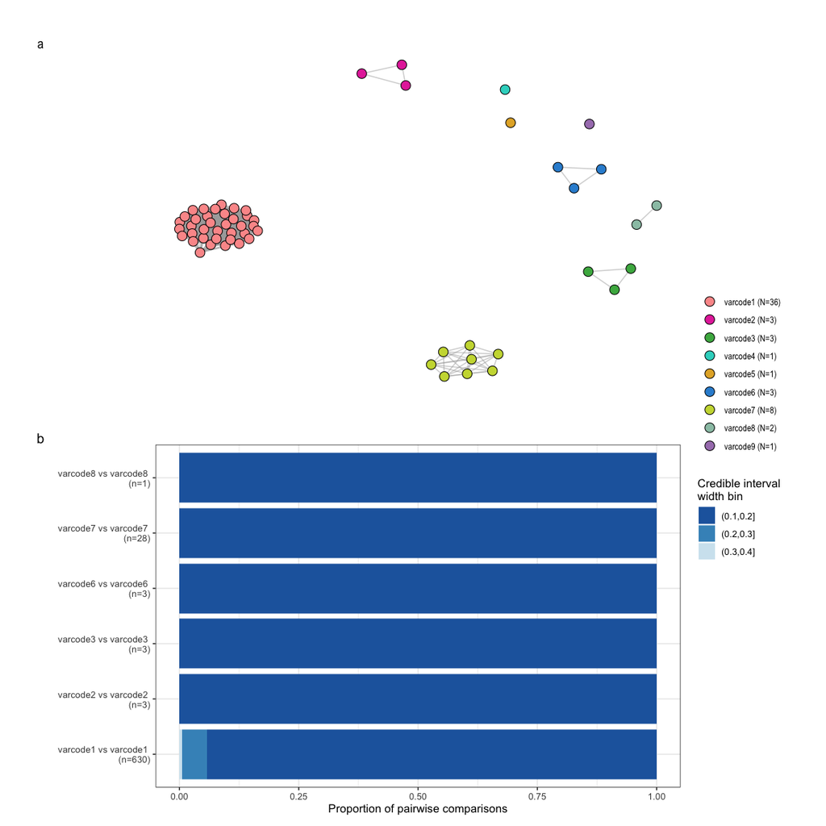

```r
plot_supp_within_varcode <- varcodes_bayesian_network / within_varcode_ci_props + plot_layout(guides = "collect") + plot_annotation(tag_levels = "a")

save_plot("viz/supp_varcode_bayesian.png", plot_supp_within_varcode, base_width = 12, base_height = 8)


plot_supp_between_varcode <- recombinants_bayesian_network / (between_varcode_ci_counts | between_varcode_ci_props ) + plot_layout(guides = "collect") + plot_annotation(tag_levels = "a")

save_plot("viz/supp_recombinants_bayesian.png", plot_supp_between_varcode, base_width = 10, base_height = 10)

plot_supp_within_varcode
```

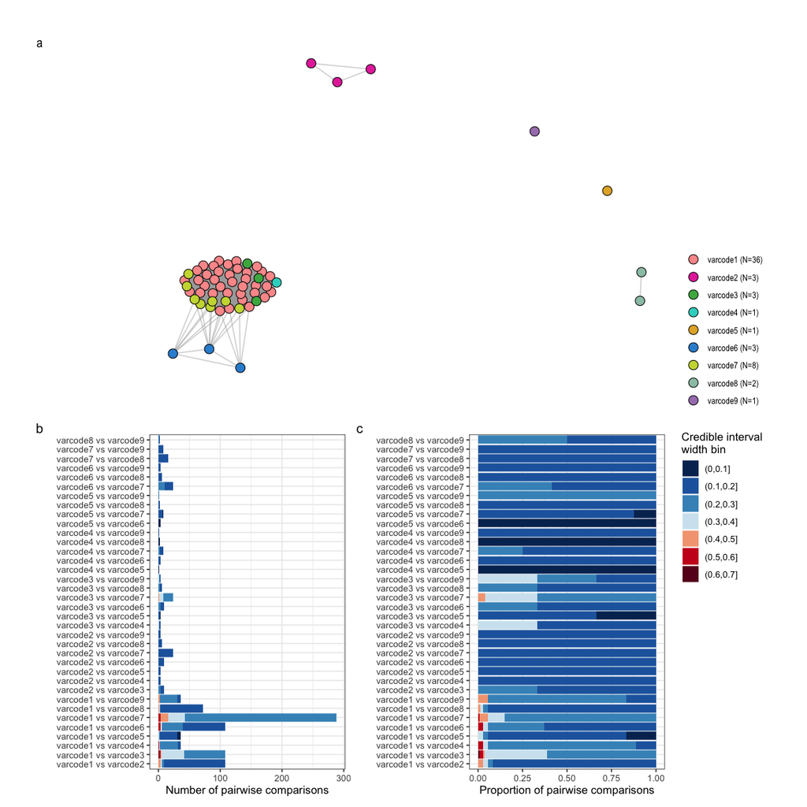

```r
plot_supp_between_varcode
```

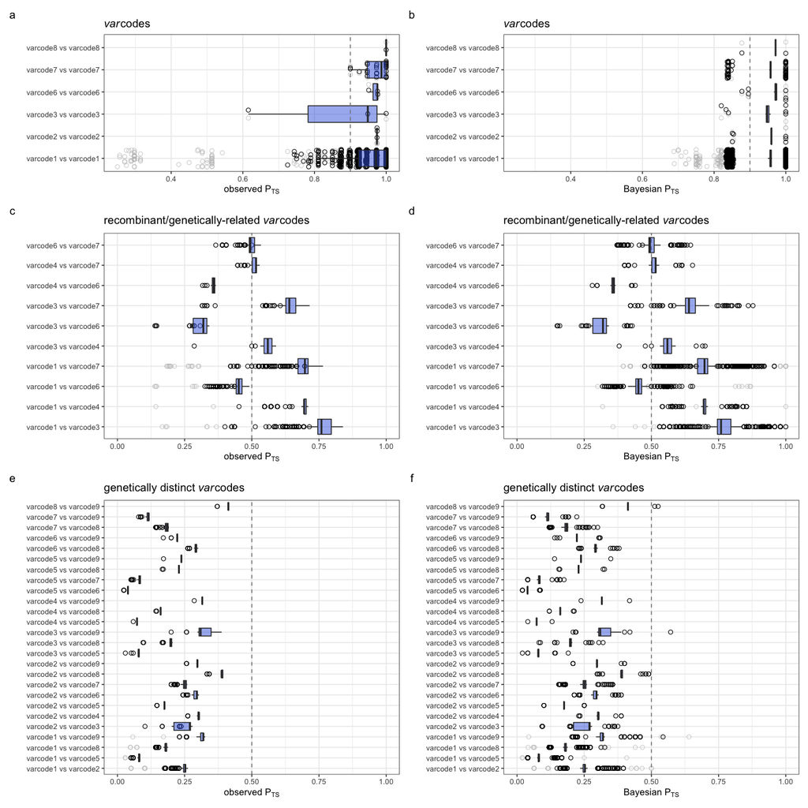